# Analysis 2024-03-04 ELISA

Taylor Lab

09 Mar 2024

### Load necessary libraries and packages

### Source Data & Functions

```r
Input_Directory <- file.path("/Users/u_lobnow/Desktop/ELISA")
NAME_KEY  <- fread(file.path(Input_Directory, "/ELISA_CL_KEY2.csv"), header = T)

# load functions
source("~/Documents/Github/Analysis_Synthethic_Myddosome/FigureScripts/functions.R")

process_data_for_plot <- function(data) {
  # Reorder cell lines for plotting
  data$CL_NAME_ON_PLOT <- reorder(data$CL_NAME_ON_PLOT, -data$ORDER_NO)

  # Reformat condition for legend text
  data$CONDITION <- factor(data$CONDITION, levels = c("UNSTIM", "STIM"))
  data$PLOTTING_COLOR[data$CONDITION == "UNSTIM"] <- "#BEBDBD"

  return(data)
}

prepare_plotting_means <- function(data) {
  # Group and summarize data for plotting_means
  plotting_means <- data %>%
    group_by(CELL_LINE, CONDITION, STIM_DAY, CL_NAME_ON_PLOT, PATHWAY, STIMULANT, STIM_CONCENTRATION, PLOTTING_COLOR, ORDER_NO) %>%
    summarise(IL2_concentration_Dilution_Factor_mean = mean(Concentration),
              Relative_Intensity_mean = mean(Concentration_NORMALIZED)) %>%
    as.data.table()

  # Round Relative_Intensity_mean
  plotting_means$Relative_Intensity_mean <- round(plotting_means$Relative_Intensity_mean, 3)

  # Reorder CL_NAME_ON_PLOT
  plotting_means$CL_NAME_ON_PLOT <- reorder(plotting_means$CL_NAME_ON_PLOT, -plotting_means$ORDER_NO)

  return(plotting_means)
}

process_statistical_analysis <- function(data, group_var, value_var) {
  # Perform statistical analysis
  statistical_significance <- perform_statistical_analysis(data, group_var, value_var)

  # Turn statistical_significance list into data.table
  stat_significance_dt <- data.table(
    CL_NAME_ON_PLOT = names(statistical_significance$annotations),
    p_value = statistical_significance$annotations,
    significance = statistical_significance$p_values
  )

  return(stat_significance_dt)
}

prepare_plotting_stats <- function(data, stat_significance_dt) {
  # Group and summarize data for plotting_stats
  plotting_stats_main <- data %>%
    group_by(CELL_LINE, CONDITION, CL_NAME_ON_PLOT, PATHWAY, STIMULANT, STIM_CONCENTRATION, PLOTTING_COLOR, ORDER_NO) %>%
    summarise(
      IL2_concentration_Dilution_Factor_mean = mean(Concentration),
      IL2_concentration_Dilution_Factor_sem = sem(Concentration),
      Relative_Intensity_mean = mean(triplicate_mean_per_day),
      Relative_Intensity_sem = sem(triplicate_mean_per_day)
    ) %>%
    as.data.table() %>%
    left_join(stat_significance_dt)

  plotting_stats_main$CONDITION <- factor(plotting_stats_main$CONDITION, levels = c("UNSTIM", "STIM"))
  plotting_stats_main$CL_NAME_ON_PLOT <- reorder(plotting_stats_main$CL_NAME_ON_PLOT, -plotting_stats_main$ORDER_NO)
  plotting_stats_main$PLOTTING_COLOR[plotting_stats_main$CONDITION == "UNSTIM"] <- "#BEBDBD"

  return(plotting_stats_main)
}
```

### Read Plates

```r
plate_data_raw <- ELISA_Fx(Input_Directory, Output_Directory)
```

```
## [1] "Plates exist!"
## [1] "Processing /Users/u_lobnow/Desktop/ELISA/Plate_1_20240304"
## [1] "Secretion = slope*Intensity"
## [1] "Secretion = 945.884037555555*Intensity"
```

```
## [1] "Processing /Users/u_lobnow/Desktop/ELISA/Plate_2_20240304"
## [1] "Secretion = slope*Intensity"
## [1] "Secretion = 1182.14278148643*Intensity"
```

```
## [1] "Processing /Users/u_lobnow/Desktop/ELISA/Plate_3_20240304"
## [1] "Secretion = slope*Intensity"
## [1] "Secretion = 1071.40830441874*Intensity"
```

```r
plate_data     <- left_join(plate_data_raw, NAME_KEY)
plate_data     <- plate_data %>% filter(CELL_LINE != "NA") %>% unique()
plate_data$CONDITION <- as.factor(plate_data$CONDITION)
```

### Manipulate Data & Plot

```r
# Data Subset
Plate_1_and_2      <- plate_data %>% filter(Plate %in% c(1,2) & Date == "2024-03-04")
Plate_1_and_2_data <- process_ELISA_data(DF = Plate_1_and_2, NEGATIVE_CTRL = "cl204", POSITIVE_CTRL = "WT_EL4")

DATA <- Plate_1_and_2_data

# Data Processing
plotting_data_main   <- process_data_for_plot(DATA)
plotting_means       <- prepare_plotting_means(data = plotting_data_main)
stat_significance_dt <- process_statistical_analysis(plotting_means, "CL_NAME_ON_PLOT", "Relative_Intensity_mean")
plotting_stats       <- prepare_plotting_stats(DATA, stat_significance_dt)

kable(stat_significance_dt)
```

| CL_NAME_ON_PLOT | p_value | significance |
| --- | --- | --- |
| CHARMS-BDLD_58 | 5.800e-02 | ns |
| CHARMS-BDLD_38 | 6.500e-01 | ns |
| CHARMS-BDLD_16 | 3.700e-01 | ns |
| CHARMS-BDLD_11 | 5.400e-01 | ns |
| tKO_EL4 | 1.000e+00 | ns |
| 3E10 | 8.600e-02 | ns |
| WT_EL4 | 1.400e-05 | **** |

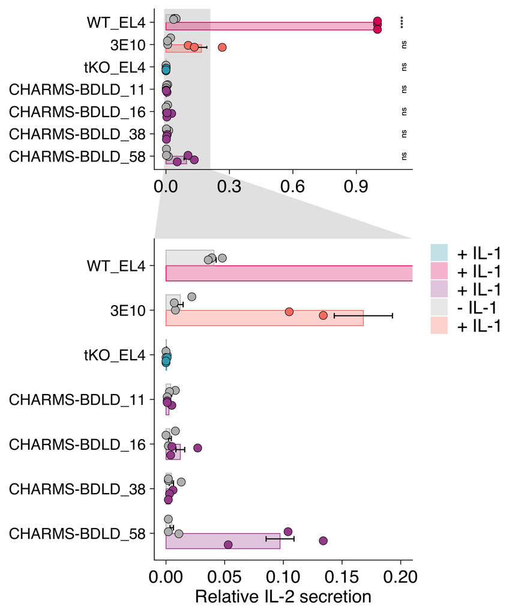

```r
# Data Plotting
X_AXIS <- "Relative IL-2 secretion"
FONT   <- "Helvetica"
SIZE   <- 25
POINTS <- 5
TEXT   <- 8
save   <- TRUE
ZOOM_LOC_X <- 0.2



rel_sec_plot <- ggplot(data = plotting_stats, aes(x = Relative_Intensity_mean, y = CL_NAME_ON_PLOT, fill = PLOTTING_COLOR, group = rev(CONDITION))) +
    geom_col(position = position_dodge(width = 0.7), aes(color = PLOTTING_COLOR), width = 0.68, alpha = 0.3) +
    geom_errorbar(data = plotting_stats, aes(y = CL_NAME_ON_PLOT,
                                             xmin = Relative_Intensity_mean - Relative_Intensity_sem,
                                             xmax = Relative_Intensity_mean + Relative_Intensity_sem),
                  linewidth = .75, position = position_dodge(width = 0.5), width = 0.25) +
    geom_point(data = plotting_means, aes(x = Relative_Intensity_mean, y = CL_NAME_ON_PLOT),
               shape = 21, size = POINTS, position = position_jitterdodge(dodge.width = 0.5, jitter.width = 0.4, seed = 750),
               show.legend = FALSE) +
    geom_text(data = plotting_stats, aes(x = max(Relative_Intensity_mean) + 0.11, y = CL_NAME_ON_PLOT, label = significance),
              hjust = .5, vjust = 1, angle = 90) +
    scale_fill_manual(name  = "CL_NAME_ON_PLOT", values = plotting_stats$PLOTTING_COLOR, breaks = plotting_stats$PLOTTING_COLOR,
                      labels = ifelse(plotting_stats$CONDITION == "UNSTIM",
                                      paste0("- ", plotting_stats$STIMULANT),
                                      paste0("+ ", plotting_stats$STIMULANT))) +
    scale_color_manual(name = "CL_NAME_ON_PLOT", values = plotting_stats$PLOTTING_COLOR, breaks = plotting_stats$PLOTTING_COLOR,
                       labels = ifelse(plotting_stats$CONDITION == "UNSTIM",
                                       paste0("- ", plotting_stats$STIMULANT),
                                       paste0("+ ", plotting_stats$STIMULANT))) +
    labs(x = X_AXIS, y = "") +
    guides(color = "none", fill = guide_legend(reverse = TRUE, ncol = 1)) +
    theme_cowplot(font_size = SIZE, font_family = FONT) +
    theme(axis.text.x       = element_text(size = SIZE, angle = 0, vjust = 0.6),
          axis.title.y      = element_blank(),
          legend.position   = "right",
          legend.title      = element_blank(),
          legend.text       = element_text(size = SIZE),
          legend.key.size   = unit(9, "mm"),
          panel.spacing.x   = unit(-5, "cm"),
          strip.text        = element_text(hjust = 0, face = "bold")) +
  facet_zoom(xlim = c(0, ZOOM_LOC_X), zoom.data = ifelse(a <= ZOOM_LOC_X, NA, FALSE))

rel_sec_plot
```

```r
# Data Subset
Plate_3      <- plate_data %>% filter(Plate == 3 & Date == "2024-03-04")
Plate_3_data <- process_ELISA_data(DF = Plate_3, NEGATIVE_CTRL = "cl204", POSITIVE_CTRL = "cl069")

DATA <- Plate_3_data

# Data Processing
plotting_data_main   <- process_data_for_plot(DATA)
plotting_means       <- prepare_plotting_means(data = plotting_data_main)
stat_significance_dt <- process_statistical_analysis(plotting_means, "CL_NAME_ON_PLOT", "Relative_Intensity_mean")
plotting_stats       <- prepare_plotting_stats(DATA, stat_significance_dt)

kable(stat_significance_dt)
```

| CL_NAME_ON_PLOT | p_value | significance |
| --- | --- | --- |
| CHARMS-BDLD_57 | 1.400e-02 | * |
| tKO_EL4 | 3.000e-01 | ns |
| cl069 | 4.800e-05 | **** |

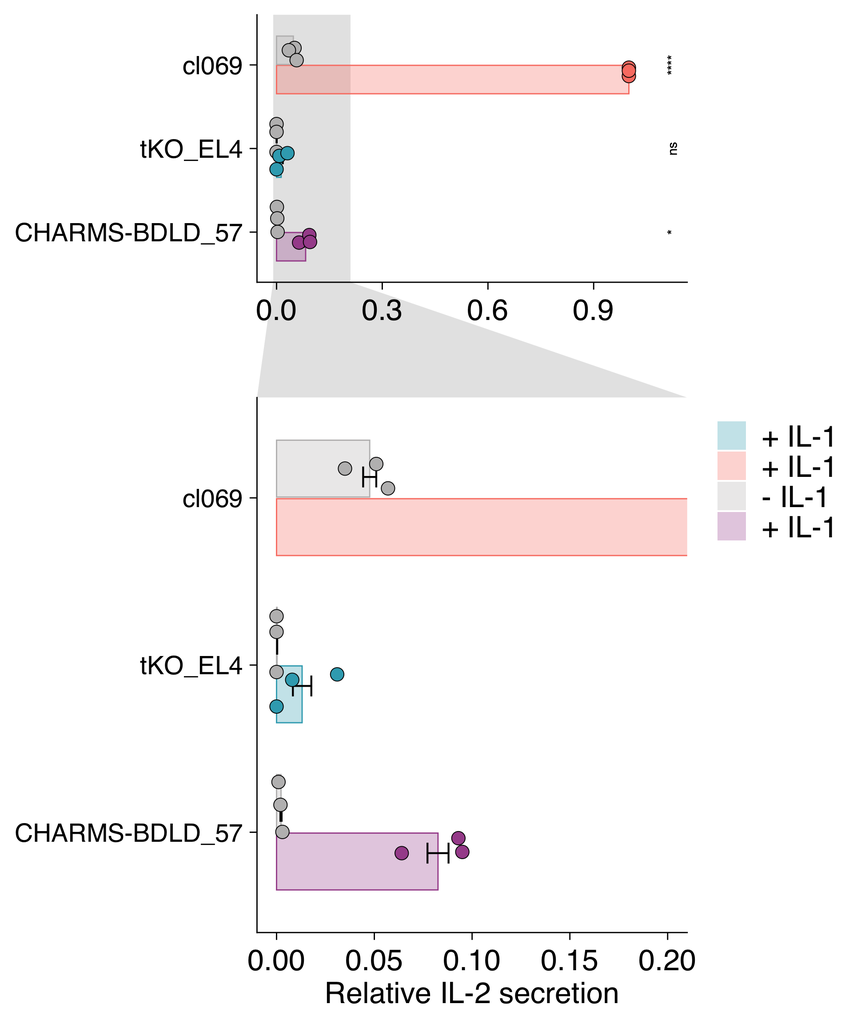

[output not shown]

[output not shown]

[output not shown]

[figure not shown]

```r
# Data Plotting
X_AXIS <- "Relative IL-2 secretion"
FONT   <- "Helvetica"
SIZE   <- 25
POINTS <- 5
TEXT   <- 8
save   <- TRUE
ZOOM_LOC_X <- 0.2

rel_sec_plot_zoom <- ggplot(data = plotting_stats, aes(x = Relative_Intensity_mean, y = CL_NAME_ON_PLOT, fill = PLOTTING_COLOR, group = rev(CONDITION))) +
    geom_col(position = position_dodge(width = 0.7), aes(color = PLOTTING_COLOR), width = 0.68, alpha = 0.3) +
    geom_errorbar(data = plotting_stats, aes(y = CL_NAME_ON_PLOT,
                                             xmin = Relative_Intensity_mean - Relative_Intensity_sem,
                                             xmax = Relative_Intensity_mean + Relative_Intensity_sem),
                  linewidth = .75, position = position_dodge(width = 0.5), width = 0.25) +
    geom_point(data = plotting_means, aes(x = Relative_Intensity_mean, y = CL_NAME_ON_PLOT),
               shape = 21, size = POINTS, position = position_jitterdodge(dodge.width = 0.5, jitter.width = 0.4, seed = 750),
               show.legend = FALSE) +
    geom_text(data = plotting_stats, aes(x = max(Relative_Intensity_mean) + 0.11, y = CL_NAME_ON_PLOT, label = significance),
              hjust = .5, vjust = 1, angle = 90) +
    scale_fill_manual(name  = "CL_NAME_ON_PLOT", values = plotting_stats$PLOTTING_COLOR, breaks = plotting_stats$PLOTTING_COLOR,
                      labels = ifelse(plotting_stats$CONDITION == "UNSTIM",
                                      paste0("- ", plotting_stats$STIMULANT),
                                      paste0("+ ", plotting_stats$STIMULANT))) +
    scale_color_manual(name = "CL_NAME_ON_PLOT", values = plotting_stats$PLOTTING_COLOR, breaks = plotting_stats$PLOTTING_COLOR,
                       labels = ifelse(plotting_stats$CONDITION == "UNSTIM",
                                       paste0("- ", plotting_stats$STIMULANT),
                                       paste0("+ ", plotting_stats$STIMULANT))) +
    labs(x = X_AXIS, y = "") +
    guides(color = "none", fill = guide_legend(reverse = TRUE, ncol = 1)) +
    theme_cowplot(font_size = SIZE, font_family = FONT) +
    theme(axis.text.x       = element_text(size = SIZE, angle = 0, vjust = 0.6),
          axis.title.y      = element_blank(),
          legend.position   = "right",
          legend.title      = element_blank(),
          legend.text       = element_text(size = SIZE),
          legend.key.size   = unit(9, "mm"),
          panel.spacing.x   = unit(-5, "cm"),
          strip.text        = element_text(hjust = 0, face = "bold")) +
  facet_zoom(xlim = c(0, ZOOM_LOC_X), zoom.data = ifelse(a <= ZOOM_LOC_X, NA, FALSE))

rel_sec_plot_zoom
```

#### STATISTICS

##### Checking for Normal distrbution with QQ-Plots

QQ plot draws the correlation between a given data and the normal distribution. Normal QQ plots are preferred because at larger sample sizes the Shapiro-Wilk test becomes very sensitive even to a minor deviation from normality.

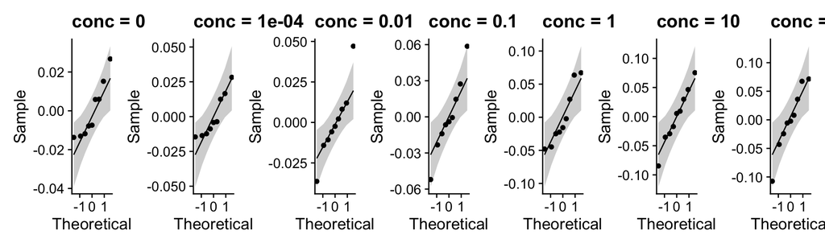

##### Checking for Normal distrbution with a Shapiro-Wilk Test

Check normality assumption by groups. Computing Shapiro-Wilk test for each group level. If the data is normally distributed, the p-value should be greater than 0.05.

| STIM_CONCENTRATION | p | normally_distributed |
| --- | --- | --- |
| 0 | 0.1438818 | TRUE |
| 1e-04 | 0.1100466 | TRUE |
| 0.01 | 0.5674296 | TRUE |
| 0.1 | 0.9357480 | TRUE |
| 1 | 0.1795030 | TRUE |
| 10 | 0.9948174 | TRUE |
| 100 | 0.7119384 | TRUE |

##### Checking for Homogneity of variance assumption with Levene

We will use the Levene’s test to check the homogeneity of variances. p-value is > 0.05, which is not significant. This means that, there is not significant difference between variances across groups. Therefore, we can assume the homogeneity of variances in the different treatment groups.

| STIM_CONCENTRATION | p | equal_variances |
| --- | --- | --- |
| 0 | 0.8411436 | TRUE |
| 1e-04 | 0.8560124 | TRUE |
| 0.01 | 0.3016913 | TRUE |
| 0.1 | 0.3506786 | TRUE |
| 1 | 0.7533702 | TRUE |
| 10 | 0.5343802 | TRUE |
| 100 | 0.4670177 | TRUE |

- ‘Dn’ and ‘DFd’ indicate the degrees of freedom in the numerator and the denominator respectively
- ‘F’ indicates that we are comparing to an F-distribution (F-test) and F is the obtained F-statistic value
- ‘p’ specifies the p-value
- ‘ges’ is the generalized effect size (generalized eta squared)

Since several concentrations have significant p-values below 0.05, there are indeed significant differences between groups.

##### One-Way ANOVA & Tukey

###### ANOVA

Since our values show homogenous variances, we can safely continue to perform a normal ANOVA test.

| STIM_CONCENTRATION | Effect | DFn | DFd | F | p | p<.05 | ges |
| --- | --- | --- | --- | --- | --- | --- | --- |
| 1e-02 | CL_NAME_ON_PLOT | 2 | 6 | 9.964 | 1.20e-02 | * | 0.769 |
| 1e+00 | CL_NAME_ON_PLOT | 2 | 6 | 19.426 | 2.00e-03 | * | 0.866 |
| 1e+01 | CL_NAME_ON_PLOT | 2 | 6 | 91.983 | 3.15e-05 | * | 0.968 |
| 1e+02 | CL_NAME_ON_PLOT | 2 | 6 | 90.734 | 3.28e-05 | * | 0.968 |

###### Tukey post-hoc

A significant one-way ANOVA is generally followed up by Tukey post-hoc tests to perform multiple pairwise comparisons between groups. Key R function: tukey_hsd() [rstatix].

- estimate: estimate of the difference between means of the two groups
- conf.low, conf.high: the lower and the upper end point of the confidence interval at 95% (default)
- p.adj: p-value after adjustment for the multiple comparisons.

| STIM_CONCENTRATION | p.adj | p.adj.signif | group1 | group2 |
| --- | --- | --- | --- | --- |
| 1e-02 | 1.28e-02 | * | 1x | 3x |
| 1e-02 | 3.69e-02 | * | 1x | 5x |
| 1e+00 | 1.93e-03 | ** | 1x | 5x |
| 1e+00 | 3.27e-02 | * | 3x | 5x |
| 1e+01 | 2.60e-04 | *** | 1x | 3x |
| 1e+01 | 2.76e-05 | **** | 1x | 5x |
| 1e+01 | 1.21e-02 | * | 3x | 5x |
| 1e+02 | 2.84e-04 | *** | 1x | 3x |
| 1e+02 | 2.84e-05 | **** | 1x | 5x |
| 1e+02 | 1.12e-02 | * | 3x | 5x |

##### Welch-ANOVA & Games-Howell

###### Welch ANOVA

In a situation where the homogeneity of variance assumption is not met, we can compute the Welch one-way ANOVA test using the function welch_anova_test()[rstatix package]. This test does not require the assumption of equal variances. It should be performed if the Levene test was significant.

| STIM_CONCENTRATION | .y. | n | statistic | DFn | DFd | p | method |
| --- | --- | --- | --- | --- | --- | --- | --- |
| 1 | Relative_Intensity_mean | 9 | 22.46 | 2 | 3.440086 | 0.011000 | Welch ANOVA |
| 10 | Relative_Intensity_mean | 9 | 168.18 | 2 | 3.706149 | 0.000231 | Welch ANOVA |
| 100 | Relative_Intensity_mean | 9 | 171.78 | 2 | 2.719304 | 0.001000 | Welch ANOVA |

###### Games-Howell

Following the Welch test, the Games-Howell post hoc test or pairwise t-tests (with no assumption of equal variances) can be used to compare all possible combinations of group differences.

| STIM_CONCENTRATION | p.adj | p.adj.signif | group1 | group2 |
| --- | --- | --- | --- | --- |
| 1 | 0.017000 | * | 1x | 5x |
| 10 | 0.009000 | ** | 1x | 3x |
| 10 | 0.000135 | *** | 1x | 5x |
| 100 | 0.008000 | ** | 1x | 3x |
| 100 | 0.004000 | ** | 1x | 5x |

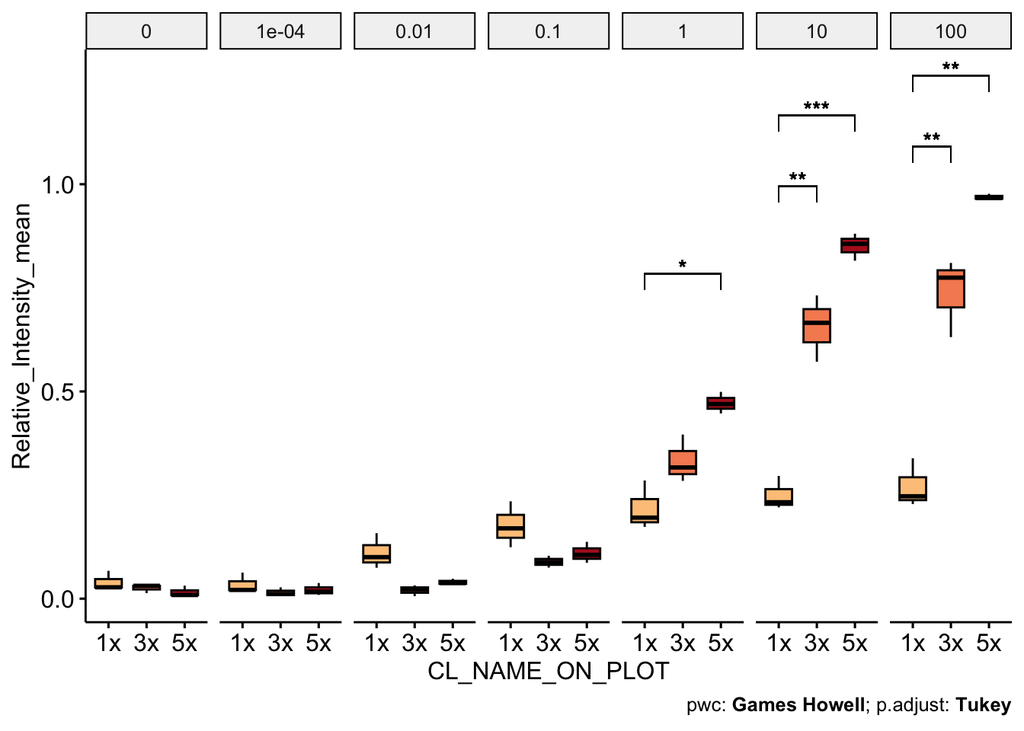

| STIM_CONCENTRATION | p.adj | p.adj.signif | group1 | group2 |
| --- | --- | --- | --- | --- |
| 1 | 0.026000 | * | 1x | 5x |
| 10 | 0.009000 | ** | 1x | 3x |
| 10 | 0.000156 | *** | 1x | 5x |
| 10 | 0.038000 | * | 3x | 5x |
| 100 | 0.007000 | ** | 1x | 3x |
| 100 | 0.006000 | ** | 1x | 5x |

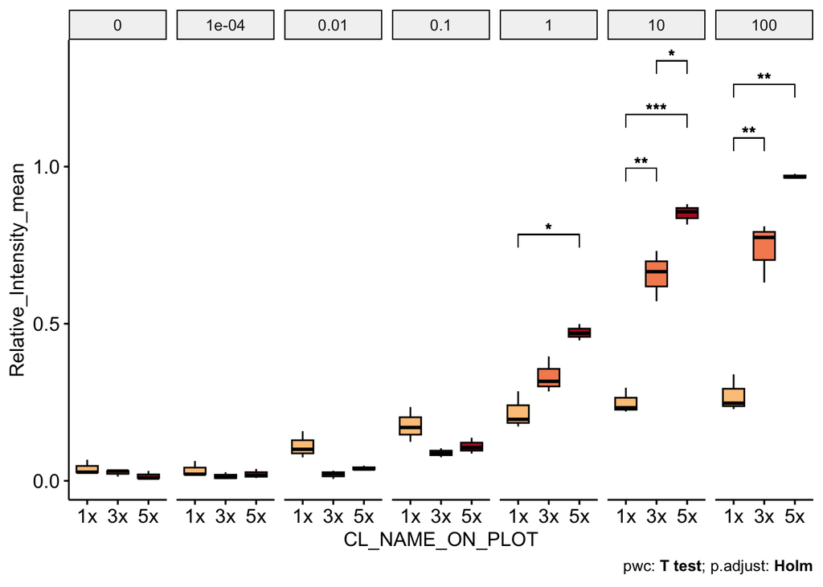

##### Kruskal-Wallis

Kruskal-Wallis test is a non-parametric alternative to the one-way ANOVA test. It extends the two-samples Wilcoxon test in the situation where there are more than two groups to compare. It’s recommended when the assumptions of one-way ANOVA test are not met.

| STIM_CONCENTRATION | .y. | n | statistic | df | p | method | p.adj.signif |
| --- | --- | --- | --- | --- | --- | --- | --- |
| 0e+00 | Relative_Intensity_mean | 9 | 1.155556 | 2 | 0.5610 | Kruskal-Wallis |  |
| 1e-04 | Relative_Intensity_mean | 9 | 1.866667 | 2 | 0.3930 | Kruskal-Wallis |  |
| 1e-02 | Relative_Intensity_mean | 9 | 7.200000 | 2 | 0.0273 | Kruskal-Wallis | * |
| 1e-01 | Relative_Intensity_mean | 9 | 5.066667 | 2 | 0.0794 | Kruskal-Wallis |  |
| 1e+00 | Relative_Intensity_mean | 9 | 6.488889 | 2 | 0.0390 | Kruskal-Wallis | * |
| 1e+01 | Relative_Intensity_mean | 9 | 7.200000 | 2 | 0.0273 | Kruskal-Wallis | * |
| 1e+02 | Relative_Intensity_mean | 9 | 7.200000 | 2 | 0.0273 | Kruskal-Wallis | * |

From the output of the Kruskal-Wallis test, we know that there are significant differences between groups, but we don’t know which pairs of groups are different.

A significant Kruskal-Wallis test is generally followed up by Dunn’s test to identify which groups are different. It’s also possible to use the Wilcoxon’s test to calculate pairwise comparisons between group levels with corrections for multiple testing.

Compared to the Wilcoxon’s test, the Dunn’s test takes into account the rankings used by the Kruskal-Wallis test. It also does ties adjustments.

| STIM_CONCENTRATION | p.adj | p.adj.signif | group1 | group2 |
| --- | --- | --- | --- | --- |
| 1e-02 | 0.0218711 | * | 1x | 3x |
| 1e+00 | 0.0338103 | * | 1x | 5x |
| 1e+01 | 0.0218711 | * | 1x | 5x |
| 1e+02 | 0.0218711 | * | 1x | 5x |

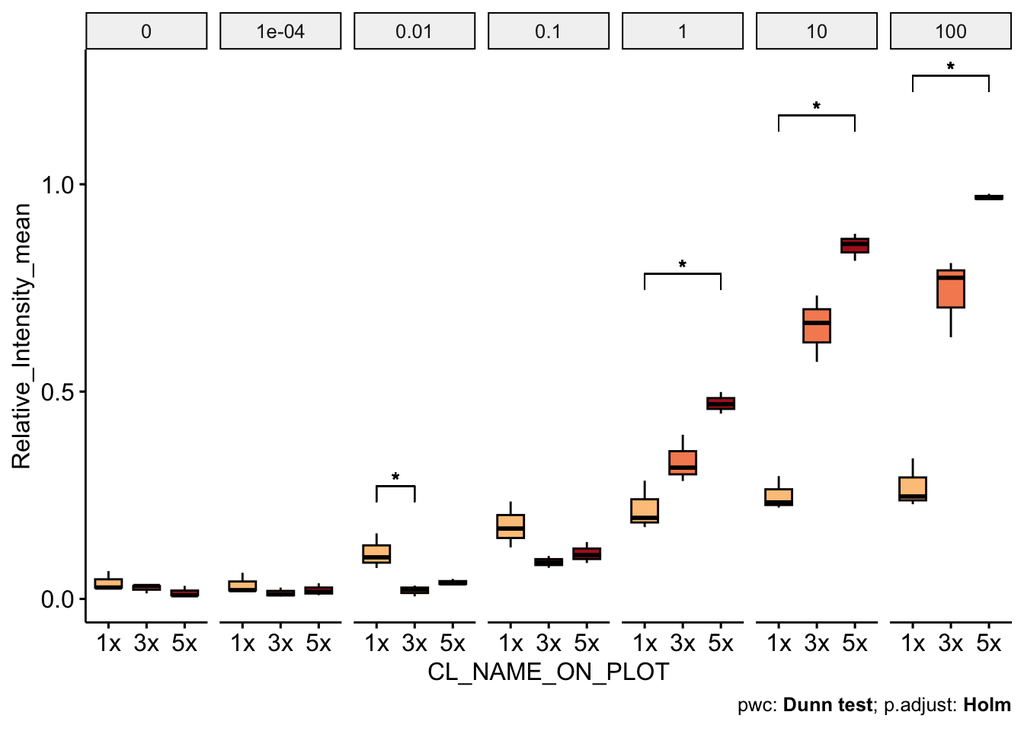

Pairwise comparisons using Wilcoxon’s test:

| STIM_CONCENTRATION | p.adj | p.adj.signif | group1 | group2 |
| --- | --- | --- | --- | --- |
| 0e+00 | 1.0 | ns | 1x | 3x |
| 0e+00 | 1.0 | ns | 1x | 5x |
| 0e+00 | 1.0 | ns | 3x | 5x |
| 1e-04 | 1.0 | ns | 1x | 3x |
| 1e-04 | 1.0 | ns | 1x | 5x |
| 1e-04 | 1.0 | ns | 3x | 5x |
| 1e-02 | 0.3 | ns | 1x | 3x |
| 1e-02 | 0.3 | ns | 1x | 5x |
| 1e-02 | 0.3 | ns | 3x | 5x |
| 1e-01 | 0.3 | ns | 1x | 3x |
| 1e-01 | 0.4 | ns | 1x | 5x |
| 1e-01 | 0.4 | ns | 3x | 5x |
| 1e+00 | 0.3 | ns | 1x | 3x |
| 1e+00 | 0.3 | ns | 1x | 5x |
| 1e+00 | 0.3 | ns | 3x | 5x |
| 1e+01 | 0.3 | ns | 1x | 3x |
| 1e+01 | 0.3 | ns | 1x | 5x |
| 1e+01 | 0.3 | ns | 3x | 5x |
| 1e+02 | 0.3 | ns | 1x | 3x |
| 1e+02 | 0.3 | ns | 1x | 5x |
| 1e+02 | 0.3 | ns | 3x | 5x |

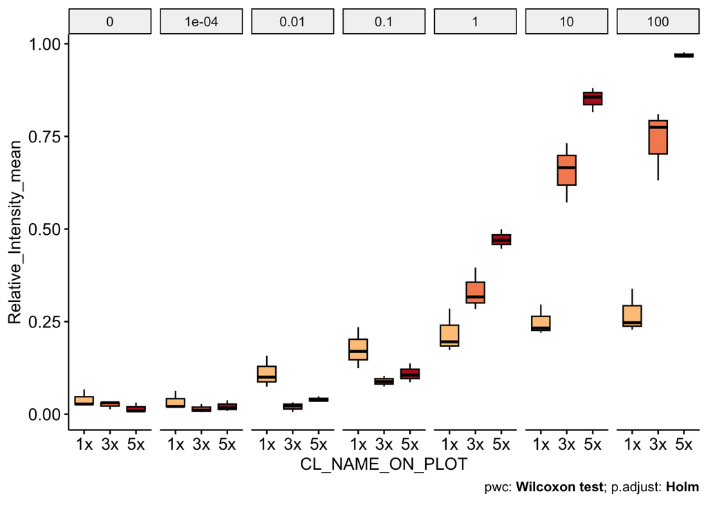